# Clustering Algorithms

### Unsupervised learning

- The algorithm tries to group similar data together (clusters)
- Using the values of the feature space

### K-Means Clusterng

- partitions the dataspace into clusters
- minimizes distance between the mean of a cluster and the data points
- the desired number of clusters must be known in advance

## Image recognition dataset

- Digits 0-9 pixelated into 64 quadrants
- Each value represents the area that is shaded

## Do imports

```python
import numpy as np
import matplotlib.pyplot as plt
%matplotlib inline
from sklearn.datasets import load_digits
from sklearn.preprocessing import scale
```

## Load data

```python
digits = load_digits()
digits
```

[output not shown]

```python
print(digits['DESCR'])
```

```
.. _digits_dataset:

Optical recognition of handwritten digits dataset
--------------------------------------------------

**Data Set Characteristics:**

    :Number of Instances: 5620
    :Number of Attributes: 64
    :Attribute Information: 8x8 image of integer pixels in the range 0..16.
    :Missing Attribute Values: None
    :Creator: E. Alpaydin (alpaydin '@' boun.edu.tr)
    :Date: July; 1998

This is a copy of the test set of the UCI ML hand-written digits datasets
https://archive.ics.uci.edu/ml/datasets/Optical+Recognition+of+Handwritten+Digits

The data set contains images of hand-written digits: 10 classes where
each class refers to a digit.

Preprocessing programs made available by NIST were used to extract
normalized bitmaps of handwritten digits from a preprinted form. From a
total of 43 people, 30 contributed to the training set and different 13
to the test set. 32x32 bitmaps are divided into nonoverlapping blocks of
4x4 and the number of on pixels are counted in each block. This generates
an input matrix of 8x8 where each element is an integer in the range
0..16. This reduces dimensionality and gives invariance to small
distortions.

For info on NIST preprocessing routines, see M. D. Garris, J. L. Blue, G.
T. Candela, D. L. Dimmick, J. Geist, P. J. Grother, S. A. Janet, and C.
L. Wilson, NIST Form-Based Handprint Recognition System, NISTIR 5469,
1994.

.. topic:: References

  - C. Kaynak (1995) Methods of Combining Multiple Classifiers and Their
    Applications to Handwritten Digit Recognition, MSc Thesis, Institute of
    Graduate Studies in Science and Engineering, Bogazici University.
  - E. Alpaydin, C. Kaynak (1998) Cascading Classifiers, Kybernetika.
  - Ken Tang and Ponnuthurai N. Suganthan and Xi Yao and A. Kai Qin.
    Linear dimensionalityreduction using relevance weighted LDA. School of
    Electrical and Electronic Engineering Nanyang Technological University.
    2005.
  - Claudio Gentile. A New Approximate Maximal Margin Classification
    Algorithm. NIPS. 2000.
```

## scale the data to normal distribution

```python
data = scale(digits.data)
```

```python
data
```

```
array([[ 0.        , -0.33501649, -0.04308102, ..., -1.14664746,
        -0.5056698 , -0.19600752],
       [ 0.        , -0.33501649, -1.09493684, ...,  0.54856067,
        -0.5056698 , -0.19600752],
       [ 0.        , -0.33501649, -1.09493684, ...,  1.56568555,
         1.6951369 , -0.19600752],
       ...,
       [ 0.        , -0.33501649, -0.88456568, ..., -0.12952258,
        -0.5056698 , -0.19600752],
       [ 0.        , -0.33501649, -0.67419451, ...,  0.8876023 ,
        -0.5056698 , -0.19600752],
       [ 0.        , -0.33501649,  1.00877481, ...,  0.8876023 ,
        -0.26113572, -0.19600752]])
```

## Render the digit images and their associated values

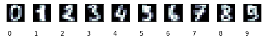

```python
def print_digits(images,y,max_n=10):
    # set up the figure size in inches
    fig = plt.figure(figsize=(12, 12))
    fig.subplots_adjust(left=0, right=1, bottom=0, top=1,
           hspace=.05, wspace=.5)
    i = 0
    while i <max_n and i <images.shape[0]:
        # plot the images in a matrix of 20x20
        p = fig.add_subplot(20, 20, i + 1, xticks=[],
              yticks=[])
        p.imshow(images[i], cmap=plt.cm.bone)
        # label the image with the target value
        p.text(0, 14, str(y[i]))
        i = i + 1
print_digits(digits.images, digits.target, max_n=10)
```

## Training and testing samples

```python
from sklearn.model_selection import train_test_split
X_train, X_test, y_train, y_test, images_train,images_test = train_test_split(
        data, digits.target, digits.images,  test_size=0.25,
          random_state=42)

n_samples, n_features = X_train.shape
n_digits = len(np.unique(y_train))
labels = y_train
```

```python
len(np.unique(y_train))
```

```
10
```

## Create the model and fit the data

```python
from sklearn import cluster
clf = cluster.KMeans(init='k-means++',n_clusters=10, random_state=42)
clf.fit(X_train)
```

```
KMeans(algorithm='auto', copy_x=True, init='k-means++', max_iter=300,
       n_clusters=10, n_init=10, n_jobs=None, precompute_distances='auto',
       random_state=42, tol=0.0001, verbose=0)
```

k-means++ runs an initializer before using the k-means algorithm

```python
images_train
```

```
array([[[ 0.,  0.,  2., ..., 16., 11.,  0.],
        [ 0.,  0.,  8., ...,  3.,  0.,  0.],
        [ 0.,  0., 13., ...,  0.,  0.,  0.],
        ...,
        [ 0.,  6., 16., ..., 16.,  5.,  0.],
        [ 0.,  0.,  3., ...,  8.,  0.,  0.],
        [ 0.,  0.,  4., ...,  0.,  0.,  0.]],

       [[ 0.,  5., 16., ...,  0.,  0.,  0.],
        [ 0., 11., 14., ...,  0.,  0.,  0.],
        [ 0.,  8., 11., ...,  0.,  0.,  0.],
        ...,
        [ 0.,  0.,  0., ...,  5.,  1.,  0.],
        [ 0.,  1., 11., ..., 16., 10.,  0.],
        [ 0.,  5., 16., ...,  6.,  1.,  0.]],

       [[ 0.,  0.,  4., ...,  0.,  0.,  0.],
        [ 0.,  0., 13., ...,  7.,  0.,  0.],
        [ 0.,  3., 16., ..., 15.,  6.,  0.],
        ...,
        [ 0.,  4., 12., ..., 11.,  6.,  0.],
        [ 0.,  0., 14., ..., 14.,  1.,  0.],
        [ 0.,  0.,  7., ...,  2.,  0.,  0.]],

       ...,

       [[ 0.,  0.,  9., ..., 13.,  1.,  0.],
        [ 0.,  0., 12., ..., 16.,  7.,  0.],
        [ 0.,  0.,  0., ..., 16.,  4.,  0.],
        ...,
        [ 0.,  0.,  7., ...,  0.,  0.,  0.],
        [ 0.,  2., 15., ...,  7.,  0.,  0.],
        [ 0.,  0.,  9., ..., 16.,  2.,  0.]],

       [[ 0.,  0.,  1., ..., 10.,  0.,  0.],
        [ 0.,  0.,  8., ..., 14.,  0.,  0.],
        [ 0.,  1., 15., ..., 15.,  0.,  0.],
        ...,
        [ 0.,  0.,  4., ...,  9.,  1.,  0.],
        [ 0.,  0.,  0., ...,  0.,  0.,  0.],
        [ 0.,  0.,  1., ...,  0.,  0.,  0.]],

       [[ 0.,  0.,  1., ...,  1.,  0.,  0.],
        [ 0.,  0.,  1., ...,  4.,  0.,  0.],
        [ 0.,  0.,  3., ...,  2.,  0.,  0.],
        ...,
        [ 0.,  0., 14., ...,  0.,  0.,  0.],
        [ 0.,  0.,  9., ...,  0.,  0.,  0.],
        [ 0.,  0.,  2., ...,  1.,  0.,  0.]]])
```

## Call print_digits with training images, and computed labels

## Returned labels are cluster numbers

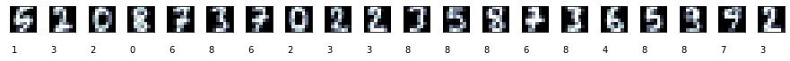

```python
print_digits(images_train, clf.labels_, max_n=20)
```

## Use test sample to generate predictions

```python
y_pred=clf.predict(X_test)
y_pred
```

```
array([4, 8, 8, 9, 3, 3, 5, 8, 5, 3, 0, 7, 1, 2, 1, 3, 8, 6, 8, 8, 1, 5,
       8, 6, 5, 4, 8, 5, 4, 8, 1, 8, 3, 1, 1, 4, 8, 1, 6, 4, 4, 8, 0, 8,
       4, 7, 8, 2, 4, 5, 5, 0, 8, 5, 4, 2, 8, 2, 2, 7, 2, 1, 5, 3, 1, 5,
       6, 2, 6, 8, 8, 8, 8, 6, 6, 2, 1, 5, 8, 8, 8, 2, 3, 8, 8, 2, 4, 1,
       1, 8, 0, 3, 7, 8, 8, 3, 8, 2, 1, 1, 1, 8, 5, 8, 7, 6, 5, 7, 1, 3,
       6, 6, 1, 1, 7, 8, 0, 6, 8, 6, 3, 4, 8, 7, 2, 6, 3, 6, 5, 0, 5, 5,
       6, 7, 2, 4, 4, 1, 3, 0, 2, 8, 1, 4, 8, 7, 4, 8, 2, 8, 8, 4, 4, 2,
       4, 1, 3, 8, 8, 6, 6, 3, 8, 2, 1, 5, 0, 4, 5, 6, 8, 0, 1, 0, 0, 8,
       6, 6, 3, 3, 8, 8, 8, 2, 8, 0, 3, 5, 4, 8, 8, 1, 0, 5, 9, 3, 8, 4,
       1, 0, 8, 8, 5, 6, 0, 8, 1, 0, 0, 5, 1, 1, 8, 4, 0, 8, 4, 2, 1, 5,
       3, 6, 7, 4, 1, 5, 4, 2, 8, 3, 8, 4, 6, 7, 8, 3, 1, 6, 4, 5, 0, 8,
       5, 0, 2, 3, 0, 0, 6, 5, 6, 4, 3, 3, 3, 8, 1, 0, 5, 8, 4, 2, 8, 6,
       6, 2, 0, 2, 1, 8, 0, 5, 8, 4, 2, 1, 3, 2, 2, 8, 4, 8, 8, 6, 8, 5,
       8, 8, 8, 0, 5, 8, 8, 7, 2, 5, 0, 8, 1, 2, 3, 1, 4, 1, 8, 1, 8, 2,
       5, 3, 3, 8, 7, 1, 0, 0, 6, 2, 0, 5, 3, 0, 0, 7, 6, 2, 4, 1, 0, 0,
       5, 0, 0, 1, 5, 5, 9, 8, 0, 4, 2, 4, 3, 2, 9, 8, 0, 8, 5, 3, 6, 6,
       7, 8, 6, 1, 8, 6, 8, 8, 4, 2, 2, 8, 2, 5, 2, 2, 1, 7, 3, 8, 0, 5,
       5, 4, 8, 0, 8, 0, 1, 3, 8, 8, 8, 8, 0, 5, 2, 4, 8, 8, 9, 0, 4, 1,
       3, 3, 7, 0, 4, 1, 6, 1, 0, 8, 1, 2, 5, 7, 8, 1, 5, 6, 4, 8, 6, 2,
       0, 8, 9, 5, 8, 6, 1, 0, 3, 8, 2, 6, 5, 6, 8, 4, 8, 8, 4, 8, 8, 2,
       0, 8, 5, 0, 6, 6, 4, 3, 4, 5])
```

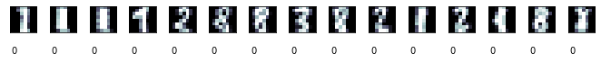

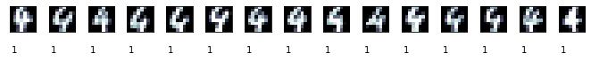

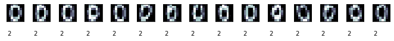

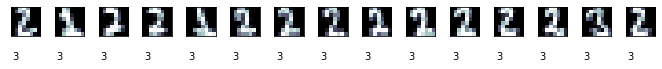

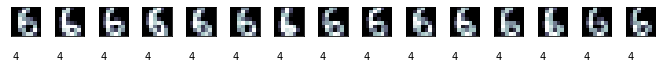

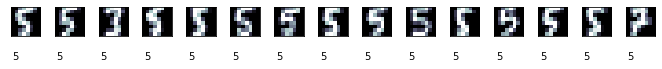

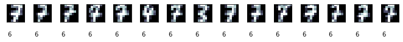

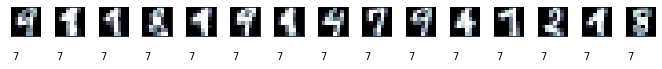

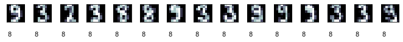

```python
def print_cluster(images, y_pred, cluster_number):
    images = images[y_pred==cluster_number]
    y_pred = y_pred[y_pred==cluster_number]
    print_digits(images, y_pred,max_n=15)
for i in range(10):
      print_cluster(images_test, y_pred, i)
```

[output not shown]

# Evaluating the model

Adjusted rand index: A measure of the similarity between two groups

We'll use it to see how similar the y_test actuals and predicted groupings are

http://scikit-learn.org/stable/modules/generated/sklearn.metrics.adjusted_rand_score.html

0.0 indicates that there is no similarity and any overlap is explainable as totally random

1.0 indicates that the two groups are identical

```python
from sklearn import metrics
print("Adjusted rand score: {0:2}".format(metrics.adjusted_rand_score(y_test, y_pred)))
```

```
Adjusted rand score: 0.5674467844660916
```

## Confusion matrix

Each row corresponds to a number (y_test)

Each column to y_pred (the cluster number)

Data is the number of times y_test was assigned to the corresponding y_pred

For example, 0 is fully assigned to cluster 2 (Row 0, Column 2)

8 is assigned to cluster 0 21 times (Row 8, Column 0)

7, which is cluster 6 is assigned to cluster 6 34 times (Row 7, Column 6)

```python
print(metrics.confusion_matrix(y_test, y_pred))
```

```
[[ 0  0 43  0  0  0  0  0  0  0]
 [20  0  0  7  0  0  0 10  0  0]
 [ 5  0  0 31  0  0  0  1  1  0]
 [ 1  0  0  1  0  1  4  0 39  0]
 [ 1 50  0  0  0  0  1  2  0  1]
 [ 1  0  0  0  1 41  0  0 16  0]
 [ 0  0  1  0 44  0  0  0  0  0]
 [ 0  0  0  0  0  1 34  1  0  5]
 [21  0  0  0  0  3  1  2 11  0]
 [ 0  0  0  0  0  2  3  3 40  0]]
```

## Graphical view of the clusters

First reduce the x dimensions to 2 using principle component analysis

https://en.wikipedia.org/wiki/Principal_component_analysis

Then figure out the range of values and define the grid

Run k-means on the reduced (2 component) data set

Draw a color map and plot the pca points on this map

Find the cluster centroids and plot them on the color map

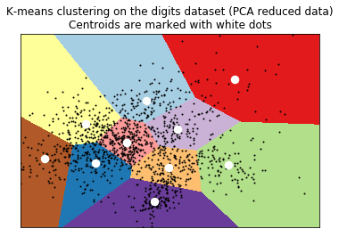

```python
from sklearn import decomposition
pca = decomposition.PCA(n_components=2).fit(X_train)
reduced_X_train = pca.transform(X_train)
# Step size of the mesh.
h = .01
# point in the mesh [x_min, m_max]x[y_min, y_max].
x_min, x_max = reduced_X_train[:, 0].min() + 1, reduced_X_train[:, 0].max() - 1
y_min, y_max = reduced_X_train[:, 1].min() + 1, reduced_X_train[:, 1].max() - 1
xx, yy = np.meshgrid(np.arange(x_min, x_max, h),
    np.arange(y_min, y_max, h))
kmeans = cluster.KMeans(init='k-means++', n_clusters=n_digits,
    n_init=10)
kmeans.fit(reduced_X_train)
Z = kmeans.predict(np.c_[xx.ravel(), yy.ravel()])
# Put the result into a color plot
Z = Z.reshape(xx.shape)
plt.figure(1)
plt.clf()
plt.imshow(Z, interpolation='nearest', extent=(xx.min(), xx.max(), yy.min(), yy.max()), cmap=plt.cm.Paired, aspect='auto', origin='lower')
plt.plot(reduced_X_train[:, 0], reduced_X_train[:, 1], 'k.',
    markersize=2)
# Plot the centroids as a white X
centroids = kmeans.cluster_centers_
plt.scatter(centroids[:, 0], centroids[:, 1],marker='.',
    s=169, linewidths=3, color='w', zorder=10)
plt.title('K-means clustering on the digits dataset (PCA reduced data)\nCentroids are marked with white dots')
plt.xlim(x_min, x_max)
plt.ylim(y_min, y_max)
plt.xticks(())
plt.yticks(())
plt.show()
```